# Práctica 1: Streaming de Datos Deportivos con Apache Kafka

Author

Alba Martínez de la Hermosa y Alonso González Romero

## 1. Introducción

Esta memoria detalla la implementación de un sistema de procesamiento de datos en tiempo real (streaming) basado en Apache Kafka. El sistema simula la ingesta y consumo de datos telemétricos de jugadores de fútbol durante un partido, procesando métricas como posición, velocidad, aceleración y frecuencia cardíaca.

## 2. Diseño de la Arquitectura de Datos

### 2.1. Diseño del Topic

Para la publicación de los eventos, se ha establecido una convención de nomenclatura jerárquica que permite escalar el sistema en el futuro.

- **Nombre del Tópico:** `futbol.partidos.sensores_fatiga.v1`
- **Justificación:** Se ha seguido el patrón de convención de nombres jerárquico estándar `dominio.subdominio.tipo.version` para garantizar la organización, escalabilidad y mantenibilidad del canal de mensajes. La elección se basa en:
  - **Dominio (`futbol`):** Define el área de negocio o macro-categoría principal (preparando el clúster por si en el futuro se integran datos de otro deporte).
  - **Subdominio (`partidos`):** Establece el contexto de recolección de los datos, separándolos claramente de otras sesiones como `entrenamientos` o `pruebas_medicas`.
  - **Tipo (`sensores_fatiga`):** Identifica el evento específico y la naturaleza de las mediciones (coordenadas, velocidad, aceleración y ritmo cardíaco).
  - **Versión (`v1`):** Es una buena práctica fundamental que permite la evolución del esquema en el futuro (por ejemplo, si se añade un sensor de temperatura corporal en la `v2`) sin romper los consumidores que dependen del formato actual.

### 2.2. Esquema de los Mensajes

Los datos se transmiten utilizando una estructura JSON, garantizando el orden, la trazabilidad de cada evento y la portabilidad a lo largo de todo el pipeline analítico.

- **Key:** Se ha utilizado el identificador del jugador (`player_id`).
  - *Motivo:* Kafka organiza sus topics en particiones usando *Append-Only Log*. Al designar el ID del jugador como Key, el algoritmo de *hashing* asegura que todos los eventos de un mismo futbolista se enruten siempre a la misma partición. Esto garantiza un procesamiento secuencial estricto, requisito indispensable para calcular métricas temporales complejas como la aceleración o la fatiga sin que los registros se desordenen.
- **Timestamp:** El tiempo del evento se extrae directamente de la columna temporal del dataset original (Event Time) y se inyecta en milisegundos a través del parámetro `timestamp_ms`. Esto evita depender del momento de recepción en el clúster (Processing Time), asegurando que la simulación refleje fielmente la cronología exacta del partido.
- **Value:** La carga útil se estructura en formato JSON siguiendo el principio de diseño de *Self-contained payload* (carga útil autocontenida). Por ello, tanto el `player_id` como el `timestamp` se han duplicado explícitamente dentro del cuerpo del mensaje. Esto asegura que el evento mantenga todo su contexto analítico en caso de ser exportado fuera del ecosistema de Kafka. Adicionalmente, se incluye la versión del esquema y un identificador único y universal (`event_id`) generado mediante la librería `uuid` para evitar la duplicidad de registros.

**Ejemplo del Payload:**

```json
{
  "schema_version": "1.0",
  "player_id": "player_5",
  "event_id": "c1b52a36-3b49-410a-b31f-0e24106512eb",
  "match_id": 1,
  "session_id": "match_1",
  "timestamp": 1711209600000,
  "bpm": 145,
  "pos_x": 45.2,
  "pos_y": 34.1,
  "speed_kmh": 21.5,
  "acceleration_ms2": 1.2
}
```

## 3. Guía de Despliegue y Ejecución

### 3.1. Archivos Entregados

El proyecto consta de los siguientes componentes principales: * `docker-compose.yml` * `producer.py` * `consumer_print.py` * `consumer_alert.py` * `memoria_ejercicio.html`

### 3.2. Paso 1: Despliegue de la Infraestructura

Para levantar el ecosistema completo, abre una terminal en la raíz del proyecto y ejecuta el orquestador de Docker en modo *detached* (segundo plano):

```bash
docker-compose up -d
```

### 3.3. Paso 2: Acceso y Preparación del Entorno

1. Abre tu navegador web y accede a la interfaz de Jupyter: `http://localhost:8888`.

[figure not shown]

   Acceso a localhost:8888

2. Desde la interfaz gráfica, abre una nueva terminal integrada.

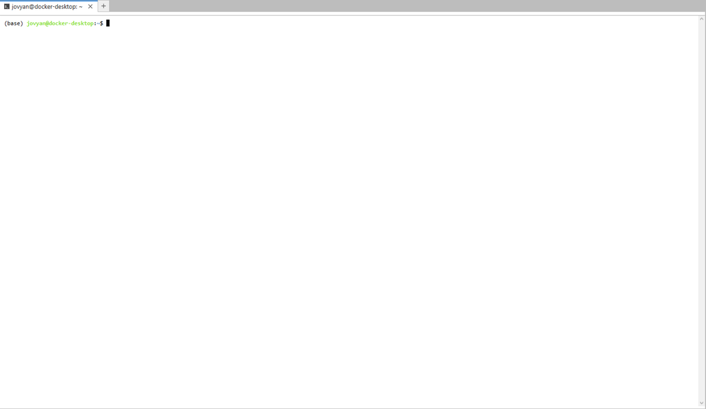

   Apertura de Terminal en Jupyter

3. Dado que los contenedores parten de una imagen base limpia, instala las dependencias necesarias de Python ejecutando:

   ```bash
   pip install kafka-python pandas
   ```

### 3.4. Paso 3: Ejecución Concurrente del Sistema

Para observar la arquitectura operando en tiempo real, abre **tres terminales independientes** dentro de Jupyter y lanza los scripts en el siguiente orden (o simultáneamente):

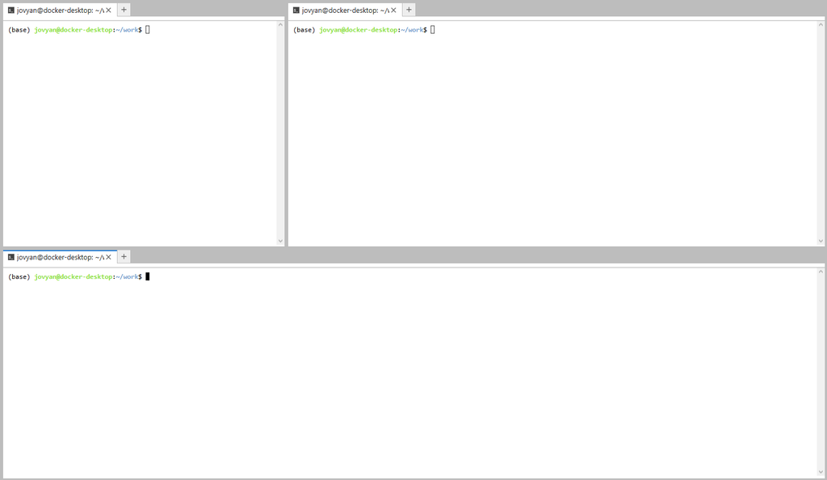

Visualización de 3 Terminales Concurrentes

- **Terminal 1 (Monitor):** `python consumer_print.py`
- **Terminal 2 (Alertas):** `python consumer_alert.py`
- **Terminal 3 (Ingesta):** `python producer.py`

*(Nota: Para detener cualquier proceso y liberar los recursos, pulsa `Ctrl + C` en su terminal correspondiente).*

### 3.5. Tolerancia a la Desincronización (Decoupling)

Una de las grandes ventajas de esta arquitectura basada en Kafka es el desacoplamiento total entre productores y consumidores, lo que garantiza que **no exista pérdida de datos independientemente del orden de ejecución**:

- **Si el Consumidor se inicia antes:** Quedará a la escucha hasta que el Productor comience a inyectar eventos.
- **Si el Productor se inicia antes:** Los mensajes serán almacenados y persistidos en los discos del Broker de Kafka. Gracias a la configuración `auto_offset_reset = 'earliest'` implementada en los consumidores, cuando estos arranquen, consumirán todo el histórico acumulado desde el principio del partido hasta alcanzar el tiempo real (Real-Time Catch-up).

## 4. Demostración del Sistema (Vídeo)

A continuación, se adjunta un vídeo demostrativo donde se puede observar la inicialización del entorno y la arquitectura procesando los eventos médicos concurrentemente:

[video not shown]